# Visualisation données brutes

Thibaut Couturier

Analyse en date du 2024-01-12

Les graphes suivants présentent, pour chacun des sites, la longueur des séries temporelles de relevés (abscisse) en fonction des effectifs moyens obtenus sur la série temporelle (ordonnées)

# Taxons retenus lors des analyses

Petit rhinolophe

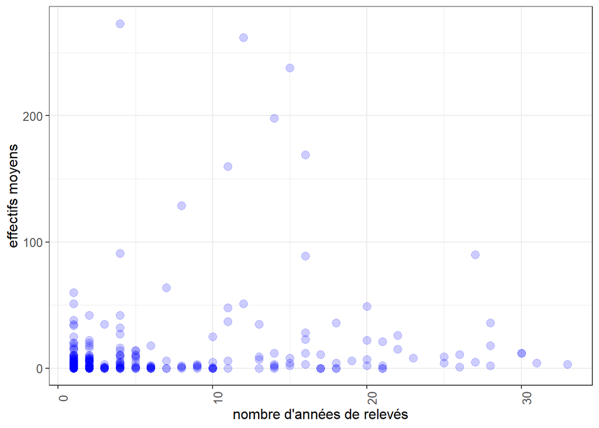

Murin de Daubenton

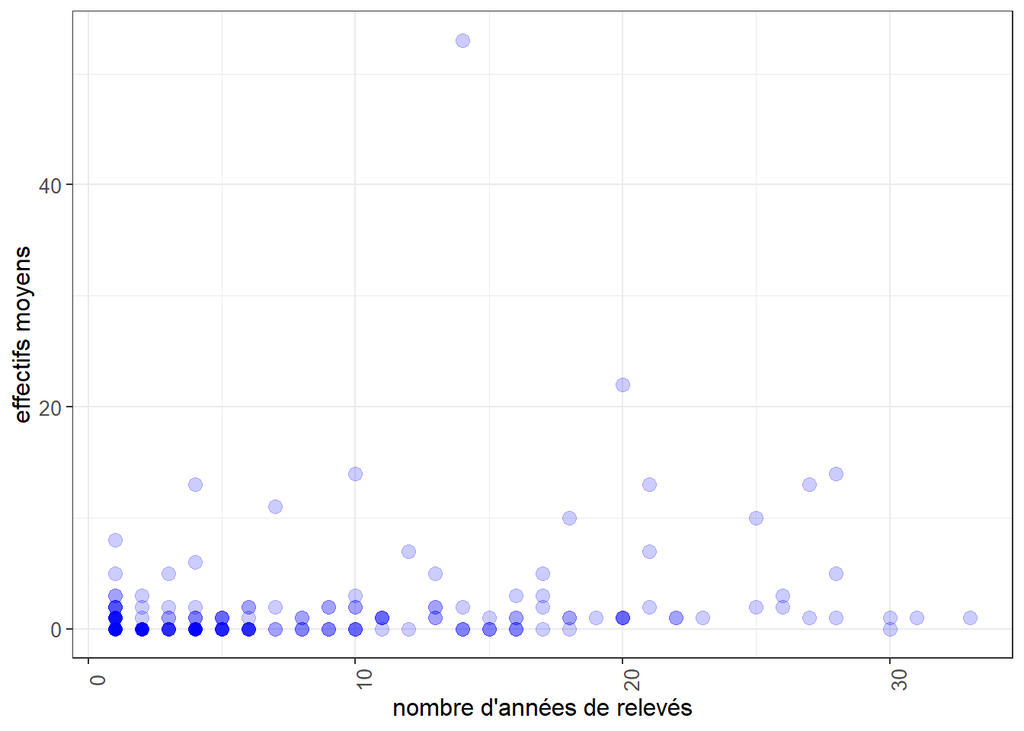

Grand murin

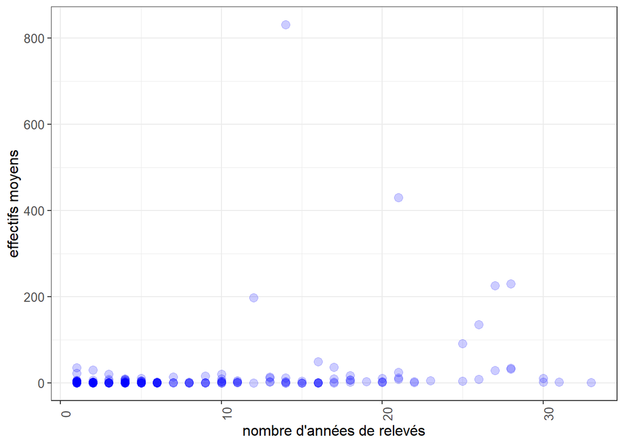

Grand rhinolophe

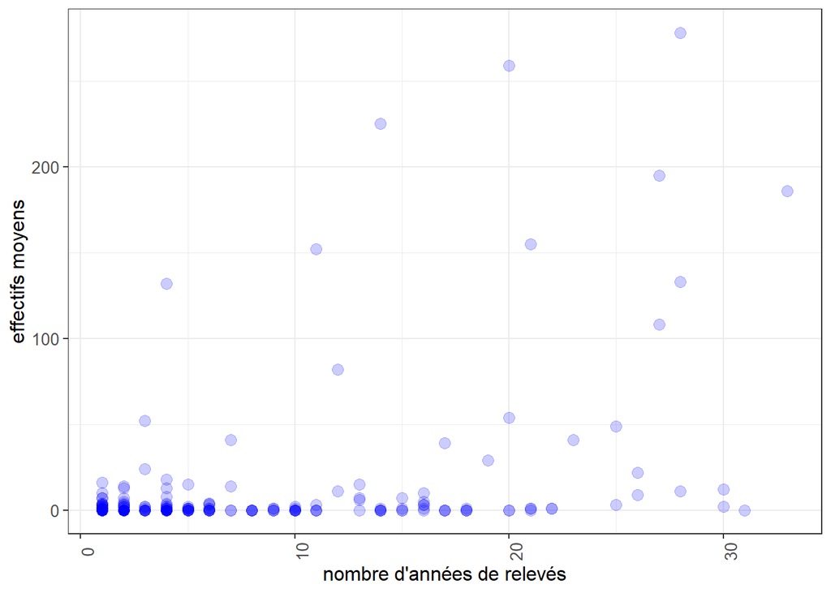

Barbastelle

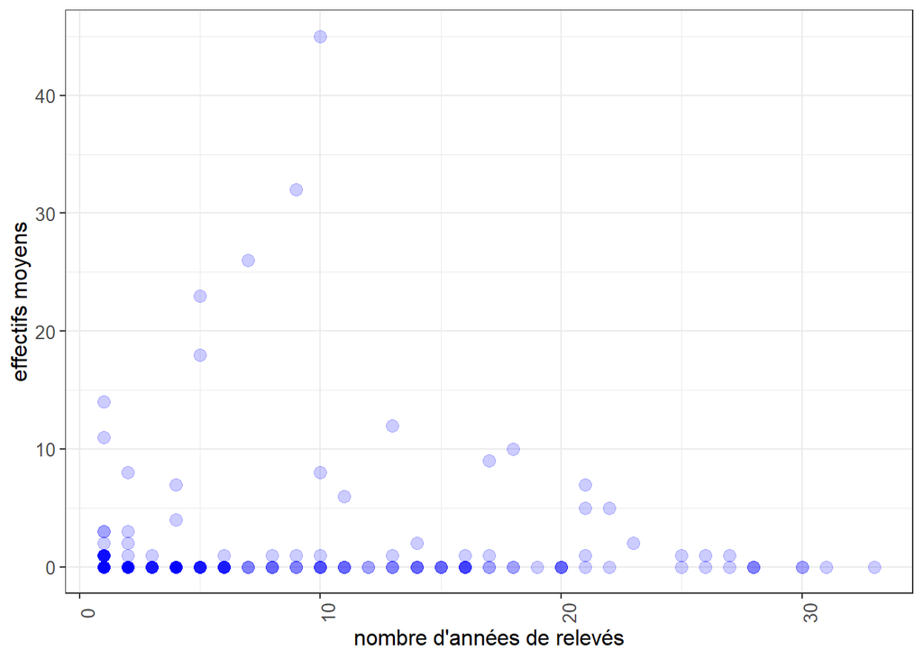

Murin à oreilles échancrées

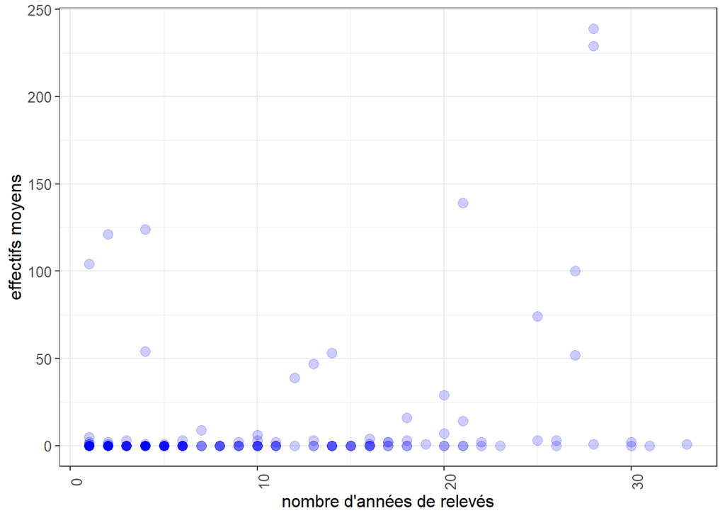

Murin de Natterer

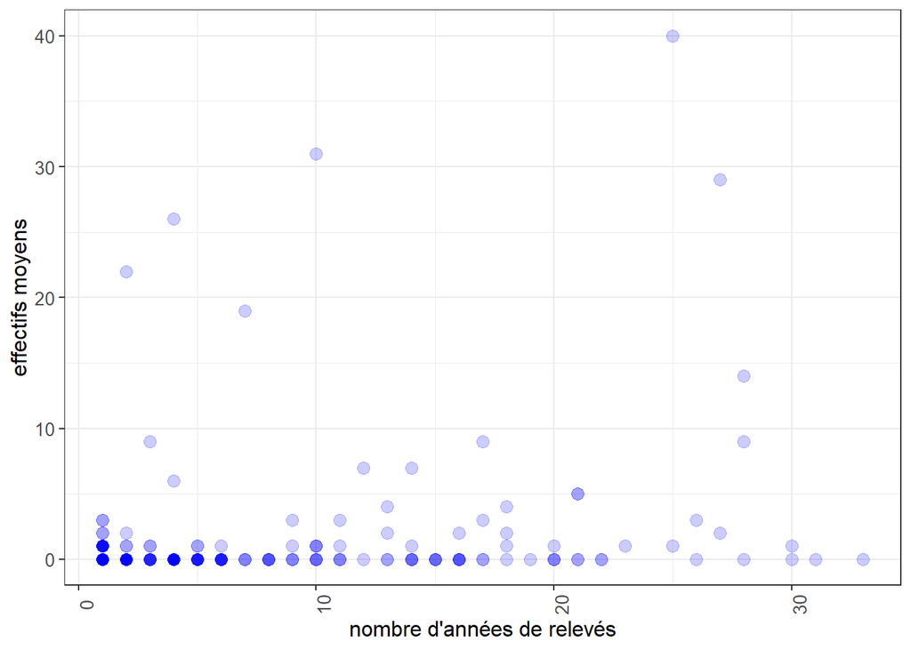

Murin de Bechstein

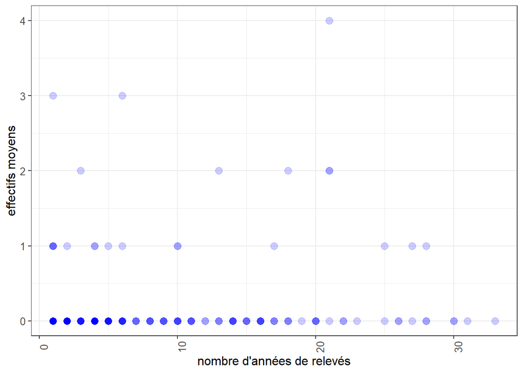

# Taxons non retenus lors de l’analyse

Rhinolophe euryale

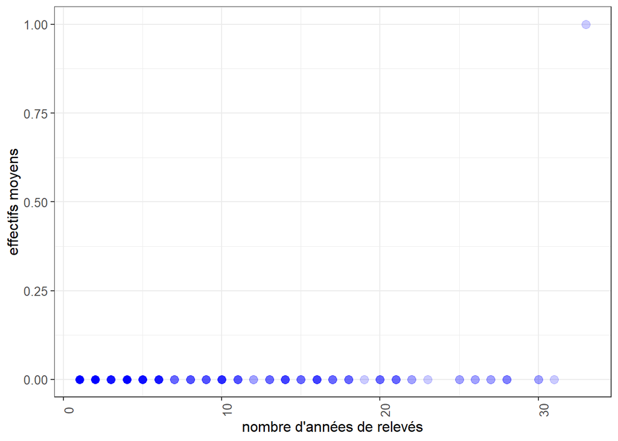

Minioptère de Schreiber

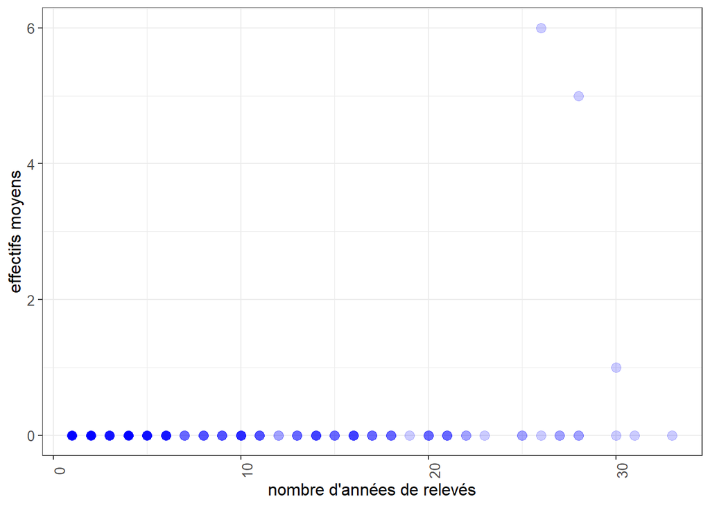

Plecotus sp.

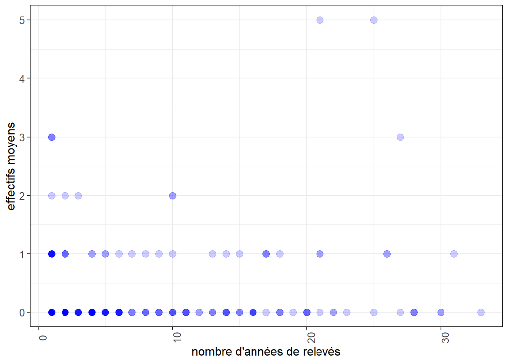

Myotis sp.

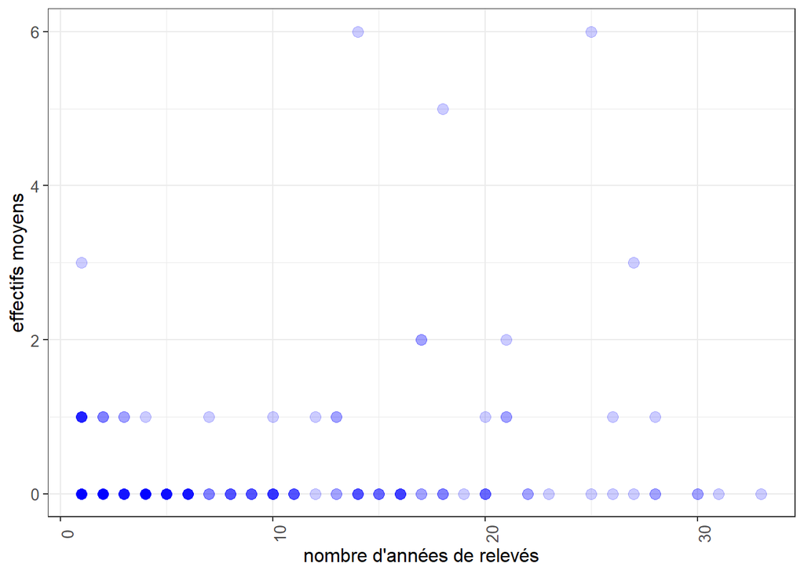

Chiroptera sp.

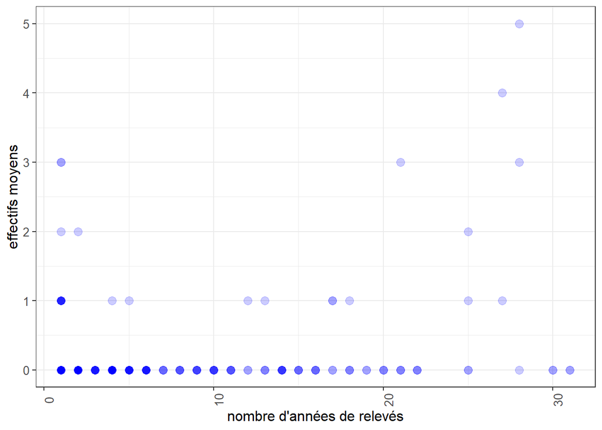

# Exploration exemple Petit rhinolophe

Le tableau suivant présente les sites échantillonnés en lignes (uniquement les 15 premiers, parmi n = 931), les années en colonnes (39), et les effectifs relevés. Les NA traduisent ainsi une absence de prospection d’un site donné une année donnée.

| CD_SITE | 1982 | 1983 | 1984 | 1985 | 1986 | 1987 | 1988 | 1989 | 1990 | 1991 | 1992 | 1993 | 1994 | 1995 | 1996 | 1997 | 1998 | 1999 | 2000 | 2001 | 2002 | 2003 | 2004 | 2005 | 2006 | 2007 | 2008 | 2009 | 2010 | … |
| --- | --- | --- | --- | --- | --- | --- | --- | --- | --- | --- | --- | --- | --- | --- | --- | --- | --- | --- | --- | --- | --- | --- | --- | --- | --- | --- | --- | --- | --- | --- |
| 21014.001 | 6 | 2 | 1 | 2 | 3 | 1 | 2 | 7 | NA | 2 | 0 | 5 | 8 | NA | NA | 6 | NA | NA | 13 | 20 | 9 | 9 | 17 | 11 | 6 | 15 | 13 | 7 | 18 | … |
| 21478.003 | 1 | 1 | 0 | NA | NA | NA | NA | NA | NA | NA | NA | NA | NA | NA | NA | NA | NA | NA | NA | NA | NA | 0 | NA | NA | NA | 0 | 0 | 0 | NA | … |
| 21485.001 | 0 | 0 | 0 | 0 | 0 | NA | 0 | NA | NA | NA | NA | NA | NA | NA | NA | 0 | 0 | 0 | 0 | 0 | 0 | 0 | 0 | 1 | 0 | 2 | 11 | 2 | 2 | … |
| 21578.002 | 1 | 0 | 1 | 0 | 3 | 0 | 2 | 2 | 0 | 2 | 2 | NA | 2 | NA | NA | 4 | NA | NA | NA | 8 | 6 | 7 | 6 | 7 | 6 | 6 | 5 | 2 | 7 | … |
| 21666.001 | 0 | 0 | 0 | 0 | NA | NA | NA | NA | NA | NA | NA | NA | NA | NA | NA | 2 | 4 | 3 | 9 | 10 | 11 | 11 | 12 | NA | 16 | 22 | 12 | 9 | 10 | … |
| 21051.002 | NA | 0 | 0 | 2 | 2 | NA | NA | NA | NA | NA | NA | NA | NA | NA | NA | NA | NA | NA | 3 | NA | NA | NA | NA | NA | NA | NA | NA | NA | NA | … |
| 21051.003 | NA | 0 | 0 | NA | NA | NA | NA | NA | NA | NA | NA | NA | NA | NA | NA | NA | NA | NA | NA | 0 | NA | 0 | 0 | 1 | 0 | 2 | 2 | 2 | NA | … |
| 21361.001 | NA | 0 | NA | NA | NA | NA | NA | NA | NA | NA | NA | NA | NA | NA | NA | NA | NA | NA | NA | NA | NA | NA | 8 | NA | NA | NA | NA | NA | NA | … |
| 21692.002 | NA | 1 | 1 | 2 | NA | NA | NA | NA | NA | NA | NA | NA | NA | NA | NA | NA | NA | NA | NA | NA | NA | NA | NA | NA | NA | NA | NA | NA | NA | … |
| 58035.001 | NA | 2 | NA | NA | NA | NA | NA | NA | NA | NA | NA | NA | NA | NA | NA | NA | NA | NA | NA | NA | NA | NA | NA | NA | NA | NA | NA | NA | NA | … |
| 21373.001 | NA | NA | 2 | 0 | 0 | NA | 0 | NA | NA | 1 | 0 | 2 | 0 | 0 | 0 | 0 | 0 | 0 | 0 | 1 | 0 | 2 | 0 | 1 | 2 | 3 | 1 | 6 | 1 | … |
| 21412.001 | NA | NA | 1 | 1 | 2 | 3 | NA | NA | NA | 0 | NA | 3 | 0 | 1 | 4 | 0 | NA | 2 | 5 | 8 | 12 | 7 | NA | 3 | 8 | 14 | 9 | 13 | 19 | … |
| 21218.002 | NA | NA | NA | 1 | NA | NA | NA | NA | NA | NA | NA | NA | NA | NA | NA | NA | NA | NA | NA | NA | NA | NA | NA | NA | NA | NA | NA | NA | NA | … |
| 58080.001 | NA | NA | NA | 3 | 7 | 1 | 8 | NA | NA | NA | NA | NA | NA | NA | NA | NA | NA | NA | NA | NA | NA | NA | NA | NA | NA | NA | NA | NA | NA | … |
| 58282.002 | NA | NA | NA | 0 | NA | NA | NA | NA | NA | NA | NA | NA | NA | NA | NA | NA | NA | NA | 0 | NA | NA | NA | NA | NA | 0 | NA | NA | NA | NA | … |

Cette proportion de NA varie entre 0.77766 et 0.99463 selon les années.

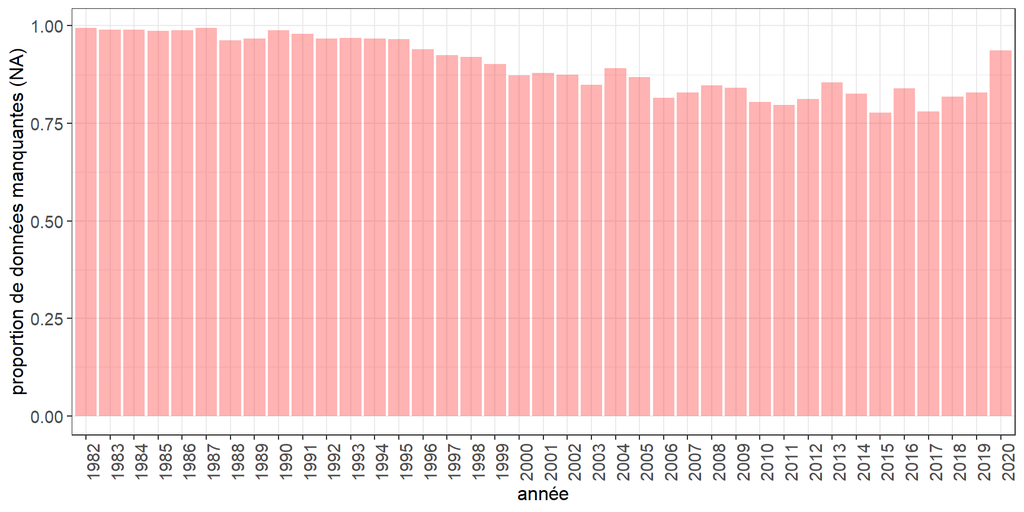

Peu de sites (n = 152) présentent des séries temporelles avec plus de 20% de relevés sur l’ensemble de la période considérée.

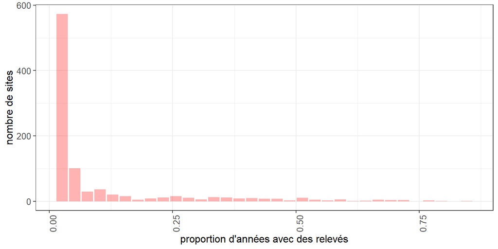

Parmi 3845 relevés de petits rhinolophes, 1459 relevés révèlent une absence de l’espèce (effectif=0).  
431 relevés ont un seul individu contacté. 110 relevés ont enregistré des effectifs supérieurs à 100 individus. L’effectif maximum enregistré est de 1142 individus.

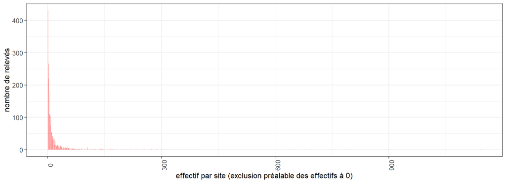

Zoom sur les relevés inférieurs à 100 :

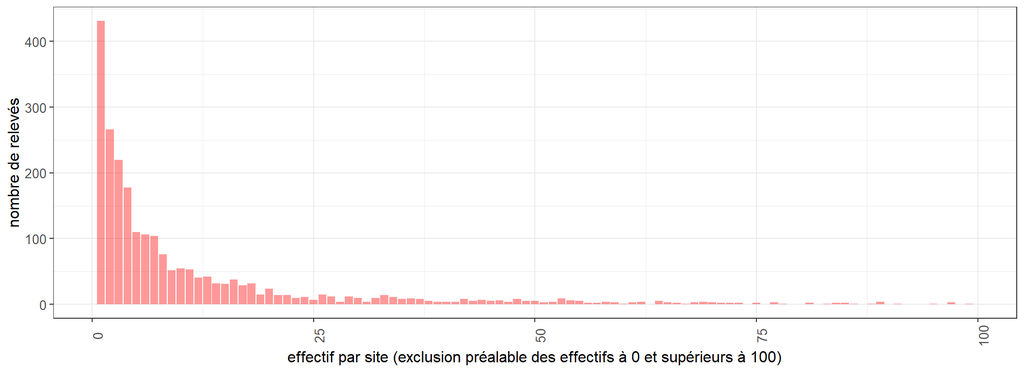

508 sites ont une moyenne de comptages en Petits rhinolophes proche de 0. 121 sites ont en moyenne un individu. Quelques sites (n = 8) abritent des effectifs supérieurs à 100 individus en moyenne.

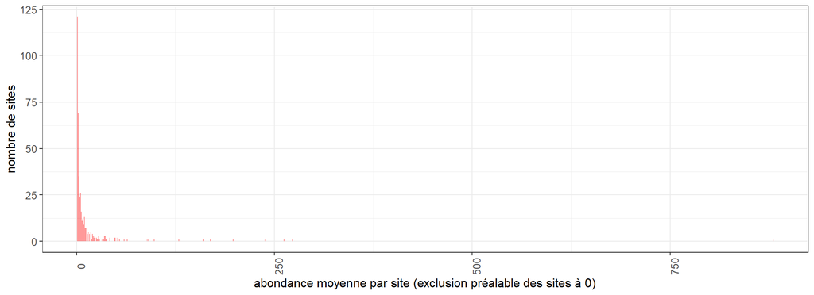

Zoom sur les sites avec effectifs moyens inférieurs à 100 :

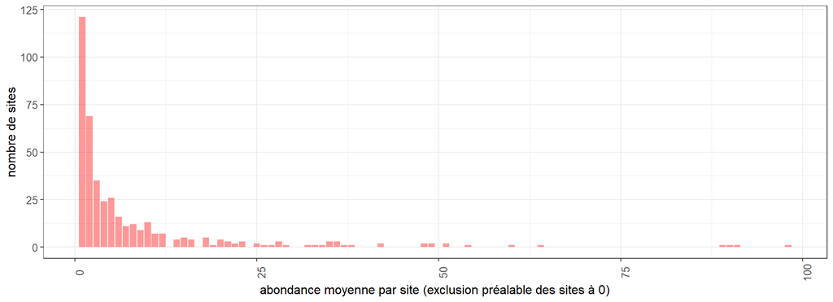

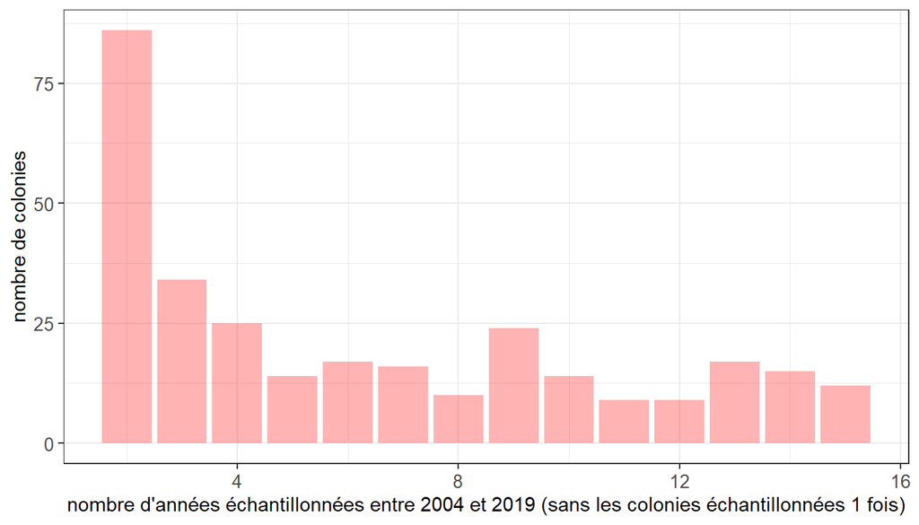

Ici les séries temporelles des effectifs des 20 plus grosses colonies (>100 individus au moins une fois) entre 2005 et 2019 (15 ans) :

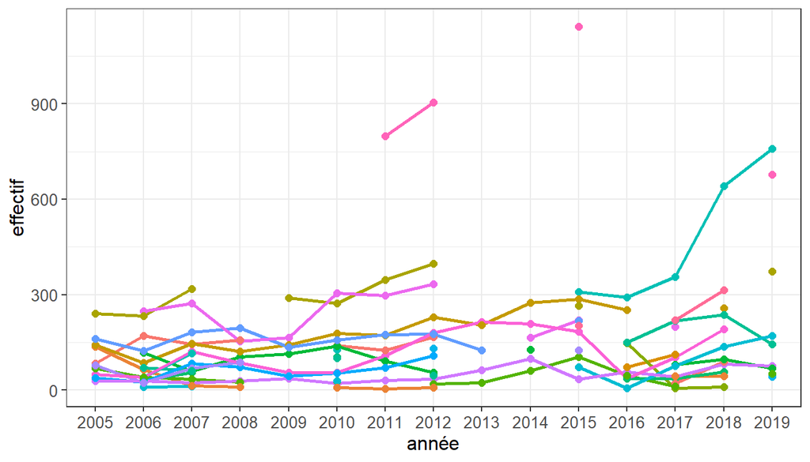

# Filtres espèces

## Echantillonnage spatial

**Tableau : Nombre de sites hivernaux disponibles après application du filtre de moins de 14 données manquantes sur site sur 15 ans par espèce**

| espece | nb_sites_filtre |
| --- | --- |
| Barbastelle | 100 |
| Murin de Bechstein | 98 |
| Murin à oreilles échancrées | 108 |
| Murin de Daubenton | 173 |
| Murin de Natterer | 153 |
| complexe Murins | 148 |
| Grand murin | 188 |
| Petit rhinolophe | 229 |
| Grand rhinolophe | 161 |

## Echantillonnage temporel

**Tableau : Nombre de sites hivernaux disponibles après application du filtre de moins de 16 données manquantes sur site sur 20 ans par espèce**

| espece | nb_sites_filtre |
| --- | --- |
| Barbastelle | 89 |
| Murin de Bechstein | 85 |
| Murin à oreilles échancrées | 98 |
| Murin de Daubenton | 139 |
| Murin de Natterer | 123 |
| complexe Murins | 115 |
| Grand murin | 138 |
| Petit rhinolophe | 144 |
| Grand rhinolophe | 121 |